# The adverse health effects of air pollution - are we making any progress?

[figure not shown]

**Credit:** [Flickr/E4C](https://www.flickr.com/people/44221799@N08/)

```python
# Load relevant packages
import pandas as pd
import numpy as np
import matplotlib.pyplot as plt
import seaborn as sns
import statsmodels.formula.api as sm
import warnings

warnings.filterwarnings("ignore")  # Suppress all warnings
```

## Introduction

**Business Context.** Air pollution is a very serious issue that the global population is currently dealing with. The abundance of air pollutants is not only contributing to global warming, but it is also causing problematic health issues to the population. There have been numerous efforts to protect and improve air quality across most nations. However, it seems that we are making very little progress. One of the main causes of this is the fact that the majority of air pollutants are derived from the burning of fossil fuels such as *coal*. Big industries and several other economical and political factors have slowed the progress towards the use of renewable energy by promoting the use of fossil fuels. Nevertheless, if we educate the general population and create awareness of this issue, we will be able to overcome this problem in the future.

For this case, you have been hired as a data science consultant for an important environmental organization. In order to promote awareness of environmental and greenhouse gas issues, your client is interested in a study of **plausible impacts of air contamination on the health of the global population**. They have gathered some *raw* data provided by the [World Health Organization](https://www.who.int/), [The Institute for Health Metrics and Evaluation](http://www.healthdata.org/) and the [World Bank Group](https://www.worldbank.org/). Your task is to conduct data analysis, search for potential information, and create visualizations that the client can use for their campaigns and grant applications.

**Analytical Context.** You are given a folder, named `files` with *raw* data. This data contains quite a large number of variables and it is in a fairly disorganized state. In addition, one of the datasets contains very poor documentation, segmented into several datasets. Your objective will be to:

1. Extract and clean the relevant data. You will have to manipulate several datasets to obtain useful information for the case.
2. Conduct Exploratory Data Analysis. You will have to create meaningful plots, formulate meaningful hypotheses and study the relationship between various indicators related to air pollution.

Additionally, the client has some broad questions they would like to answer:  
1. Are we making any progress in reducing the amount of emitted pollutants across the globe?  
2. Which are the critical regions where we should start environmental campaigns?  
3. Are we making any progress in the prevention of deaths related to air pollution?  
4. Which demographic characteristics seem to correlate with the number of health-related issues derived from air pollution?

## Extracting and cleaning relevant data

Let's take a look at the data provided by the client in the `files` folder. There, we see another folder named `WDI_csv` with several CSV files corresponding to the World Bank's primary [World Development Indicators](https://datacatalog.worldbank.org/dataset/world-development-indicators). The client stated that this data may contain some useful information relevant to our study, but they have not told us anything aside from that. Thus, we are on our own in finding and extracting the relevant data for our study. This we will do next.

Let's take a peek at the file `WDIData.csv`:

```python
WDI_data = pd.read_csv("./files/WDI_csv/WDIData.csv")
print(WDI_data.columns)
print(WDI_data.info())
WDI_data.head()
```

```
Index(['Country Name', 'Country Code', 'Indicator Name', 'Indicator Code',
       '1960', '1961', '1962', '1963', '1964', '1965', '1966', '1967', '1968',
       '1969', '1970', '1971', '1972', '1973', '1974', '1975', '1976', '1977',
       '1978', '1979', '1980', '1981', '1982', '1983', '1984', '1985', '1986',
       '1987', '1988', '1989', '1990', '1991', '1992', '1993', '1994', '1995',
       '1996', '1997', '1998', '1999', '2000', '2001', '2002', '2003', '2004',
       '2005', '2006', '2007', '2008', '2009', '2010', '2011', '2012', '2013',
       '2014', '2015', '2016', '2017', '2018', '2019', 'Unnamed: 64'],
      dtype='object')
<class 'pandas.core.frame.DataFrame'>
RangeIndex: 377256 entries, 0 to 377255
Data columns (total 65 columns):
 #   Column          Non-Null Count   Dtype
---  ------          --------------   -----
 0   Country Name    377256 non-null  object
```

[output cut: 67 more lines]

|  | Country Name | Country Code | Indicator Name | Indicator Code | 1960 | 1961 | 1962 | 1963 | 1964 | 1965 | ... | 2011 | 2012 | 2013 | 2014 | 2015 | 2016 | 2017 | 2018 | 2019 | Unnamed: 64 |
| --- | --- | --- | --- | --- | --- | --- | --- | --- | --- | --- | --- | --- | --- | --- | --- | --- | --- | --- | --- | --- | --- |
| 0 | Arab World | ARB | 2005 PPP conversion factor, GDP (LCU per inter... | PA.NUS.PPP.05 | NaN | NaN | NaN | NaN | NaN | NaN | ... | NaN | NaN | NaN | NaN | NaN | NaN | NaN | NaN | NaN | NaN |
| 1 | Arab World | ARB | 2005 PPP conversion factor, private consumptio... | PA.NUS.PRVT.PP.05 | NaN | NaN | NaN | NaN | NaN | NaN | ... | NaN | NaN | NaN | NaN | NaN | NaN | NaN | NaN | NaN | NaN |
| 2 | Arab World | ARB | Access to clean fuels and technologies for coo... | EG.CFT.ACCS.ZS | NaN | NaN | NaN | NaN | NaN | NaN | ... | 82.783289 | 83.120303 | 83.533457 | 83.897596 | 84.171599 | 84.510171 | NaN | NaN | NaN | NaN |
| 3 | Arab World | ARB | Access to electricity (% of population) | EG.ELC.ACCS.ZS | NaN | NaN | NaN | NaN | NaN | NaN | ... | 86.428272 | 87.070576 | 88.176836 | 87.342739 | 89.130121 | 89.678685 | 90.273687 | NaN | NaN | NaN |
| 4 | Arab World | ARB | Access to electricity, rural (% of rural popul... | EG.ELC.ACCS.RU.ZS | NaN | NaN | NaN | NaN | NaN | NaN | ... | 73.942103 | 75.244104 | 77.162305 | 75.538976 | 78.741152 | 79.665635 | 80.749293 | NaN | NaN | NaN |

5 rows × 65 columns

The data seems to have a large number of indicators dating from 1960. There are also columns containing country names and codes. Notice that the first couple of rows say `Arab World`, which may indicate that the data contains broad regional data as well. We notice also that there are at least 100,000 entries with `NaN` values for each year column.

Since we are interested in environmental indicators, we must get rid of any rows not relevant to our study. However, the number of indicators seems to be quite large and a manual inspection seems impossible. Let's load the file `WDISeries.csv` which seems to contain more information about the indicators:

```python
WDI_ids = pd.read_csv("./files/WDI_csv/WDISeries.csv")
print(WDI_ids.columns)
WDI_ids.head()
```

```
Index(['Series Code', 'Topic', 'Indicator Name', 'Short definition',
       'Long definition', 'Unit of measure', 'Periodicity', 'Base Period',
       'Other notes', 'Aggregation method', 'Limitations and exceptions',
       'Notes from original source', 'General comments', 'Source',
       'Statistical concept and methodology', 'Development relevance',
       'Related source links', 'Other web links', 'Related indicators',
       'License Type', 'Unnamed: 20'],
      dtype='object')
```

|  | Series Code | Topic | Indicator Name | Short definition | Long definition | Unit of measure | Periodicity | Base Period | Other notes | Aggregation method | ... | Notes from original source | General comments | Source | Statistical concept and methodology | Development relevance | Related source links | Other web links | Related indicators | License Type | Unnamed: 20 |
| --- | --- | --- | --- | --- | --- | --- | --- | --- | --- | --- | --- | --- | --- | --- | --- | --- | --- | --- | --- | --- | --- |
| 0 | AG.AGR.TRAC.NO | Environment: Agricultural production | Agricultural machinery, tractors | NaN | Agricultural machinery refers to the number of... | NaN | Annual | NaN | NaN | Sum | ... | NaN | NaN | Food and Agriculture Organization, electronic ... | A tractor provides the power and traction to m... | Agricultural land covers more than one-third o... | NaN | NaN | NaN | CC BY-4.0 | NaN |
| 1 | AG.CON.FERT.PT.ZS | Environment: Agricultural production | Fertilizer consumption (% of fertilizer produc... | NaN | Fertilizer consumption measures the quantity o... | NaN | Annual | NaN | NaN | Weighted average | ... | NaN | NaN | Food and Agriculture Organization, electronic ... | Fertilizer consumption measures the quantity o... | Factors such as the green revolution, has led ... | NaN | NaN | NaN | CC BY-4.0 | NaN |
| 2 | AG.CON.FERT.ZS | Environment: Agricultural production | Fertilizer consumption (kilograms per hectare ... | NaN | Fertilizer consumption measures the quantity o... | NaN | Annual | NaN | NaN | Weighted average | ... | NaN | NaN | Food and Agriculture Organization, electronic ... | Fertilizer consumption measures the quantity o... | Factors such as the green revolution, has led ... | NaN | NaN | NaN | CC BY-4.0 | NaN |
| 3 | AG.LND.AGRI.K2 | Environment: Land use | Agricultural land (sq. km) | NaN | Agricultural land refers to the share of land ... | NaN | Annual | NaN | NaN | Sum | ... | NaN | NaN | Food and Agriculture Organization, electronic ... | Agricultural land constitutes only a part of a... | Agricultural land covers more than one-third o... | NaN | NaN | NaN | CC BY-4.0 | NaN |
| 4 | AG.LND.AGRI.ZS | Environment: Land use | Agricultural land (% of land area) | NaN | Agricultural land refers to the share of land ... | NaN | Annual | NaN | NaN | Weighted average | ... | NaN | NaN | Food and Agriculture Organization, electronic ... | Agriculture is still a major sector in many ec... | Agricultural land covers more than one-third o... | NaN | NaN | NaN | CC BY-4.0 | NaN |

5 rows × 21 columns

Bingo! The `WDI_ids` DataFrame contains a column named `Topic`. Moreover, it seems that *Environment* is listed as a key topic in the column.

### Exercise 1:

Extract all the rows that have the topic key *Environment* in `WDI_ids`. Add to the resulting DataFrame a new column named `Subtopic` which contains the corresponding subtopic of the indicator. For example, the subtopic of `Environment: Agricultural production` is `Agricultural production`. Which subtopics do you think are of interest to us?

**Hint:** Remember that you can apply string methods to Series using the `str()` method of `pandas`.

**Answer.**

```python
filtWDI_ids = WDI_ids[WDI_ids['Topic'].apply(lambda x: 'Environment' in x)]\
.reset_index(drop=True)
```

```python
filtWDI_ids['Subtopic'] = filtWDI_ids['Topic'].str.replace('Environment: ', '')
filtWDI_ids.head(5)
```

|  | Series Code | Topic | Indicator Name | Short definition | Long definition | Unit of measure | Periodicity | Base Period | Other notes | Aggregation method | ... | General comments | Source | Statistical concept and methodology | Development relevance | Related source links | Other web links | Related indicators | License Type | Unnamed: 20 | Subtopic |
| --- | --- | --- | --- | --- | --- | --- | --- | --- | --- | --- | --- | --- | --- | --- | --- | --- | --- | --- | --- | --- | --- |
| 0 | AG.AGR.TRAC.NO | Environment: Agricultural production | Agricultural machinery, tractors | NaN | Agricultural machinery refers to the number of... | NaN | Annual | NaN | NaN | Sum | ... | NaN | Food and Agriculture Organization, electronic ... | A tractor provides the power and traction to m... | Agricultural land covers more than one-third o... | NaN | NaN | NaN | CC BY-4.0 | NaN | Agricultural production |
| 1 | AG.CON.FERT.PT.ZS | Environment: Agricultural production | Fertilizer consumption (% of fertilizer produc... | NaN | Fertilizer consumption measures the quantity o... | NaN | Annual | NaN | NaN | Weighted average | ... | NaN | Food and Agriculture Organization, electronic ... | Fertilizer consumption measures the quantity o... | Factors such as the green revolution, has led ... | NaN | NaN | NaN | CC BY-4.0 | NaN | Agricultural production |
| 2 | AG.CON.FERT.ZS | Environment: Agricultural production | Fertilizer consumption (kilograms per hectare ... | NaN | Fertilizer consumption measures the quantity o... | NaN | Annual | NaN | NaN | Weighted average | ... | NaN | Food and Agriculture Organization, electronic ... | Fertilizer consumption measures the quantity o... | Factors such as the green revolution, has led ... | NaN | NaN | NaN | CC BY-4.0 | NaN | Agricultural production |
| 3 | AG.LND.AGRI.K2 | Environment: Land use | Agricultural land (sq. km) | NaN | Agricultural land refers to the share of land ... | NaN | Annual | NaN | NaN | Sum | ... | NaN | Food and Agriculture Organization, electronic ... | Agricultural land constitutes only a part of a... | Agricultural land covers more than one-third o... | NaN | NaN | NaN | CC BY-4.0 | NaN | Land use |
| 4 | AG.LND.AGRI.ZS | Environment: Land use | Agricultural land (% of land area) | NaN | Agricultural land refers to the share of land ... | NaN | Annual | NaN | NaN | Weighted average | ... | NaN | Food and Agriculture Organization, electronic ... | Agriculture is still a major sector in many ec... | Agricultural land covers more than one-third o... | NaN | NaN | NaN | CC BY-4.0 | NaN | Land use |

5 rows × 22 columns

### Exercise 2:

Use the results of Exercise 1 to create a new DataFrame with the history of all emissions indicators for countries and major regions. Call this new DataFrame `Emissions_df`. How many emissions indicators are in the study?

**Answer.**

```python
print(filtWDI_ids.columns)
print(WDI_data.columns)
```

```
Index(['Series Code', 'Topic', 'Indicator Name', 'Short definition',
       'Long definition', 'Unit of measure', 'Periodicity', 'Base Period',
       'Other notes', 'Aggregation method', 'Limitations and exceptions',
       'Notes from original source', 'General comments', 'Source',
       'Statistical concept and methodology', 'Development relevance',
       'Related source links', 'Other web links', 'Related indicators',
       'License Type', 'Unnamed: 20', 'Subtopic'],
      dtype='object')
Index(['Country Name', 'Country Code', 'Indicator Name', 'Indicator Code',
       '1960', '1961', '1962', '1963', '1964', '1965', '1966', '1967', '1968',
       '1969', '1970', '1971', '1972', '1973', '1974', '1975', '1976', '1977',
       '1978', '1979', '1980', '1981', '1982', '1983', '1984', '1985', '1986',
       '1987', '1988', '1989', '1990', '1991', '1992', '1993', '1994', '1995',
       '1996', '1997', '1998', '1999', '2000', '2001', '2002', '2003', '2004',
       '2005', '2006', '2007', '2008', '2009', '2010', '2011', '2012', '2013',
       '2014', '2015', '2016', '2017', '2018', '2019', 'Unnamed: 64'],
      dtype='object')
```

```python
Emissions_df = filtWDI_ids[filtWDI_ids['Subtopic'] == 'Emissions']\
.merge(WDI_data, how='inner', left_on='Series Code', right_on='Indicator Code')
print(Emissions_df.info())
print(Emissions_df.columns)
Emissions_df.head(5)
```

```
<class 'pandas.core.frame.DataFrame'>
Int64Index: 11088 entries, 0 to 11087
Data columns (total 87 columns):
 #   Column                               Non-Null Count  Dtype
---  ------                               --------------  -----
 0   Series Code                          11088 non-null  object
 1   Topic                                11088 non-null  object
 2   Indicator Name_x                     11088 non-null  object
 3   Short definition                     0 non-null      object
 4   Long definition                      11088 non-null  object
 5   Unit of measure                      0 non-null      object
 6   Periodicity                          11088 non-null  object
 7   Base Period                          528 non-null    object
 8   Other notes                          0 non-null      object
 9   Aggregation method                   10824 non-null  object
```

[output cut: 96 more lines]

|  | Series Code | Topic | Indicator Name_x | Short definition | Long definition | Unit of measure | Periodicity | Base Period | Other notes | Aggregation method | ... | 2011 | 2012 | 2013 | 2014 | 2015 | 2016 | 2017 | 2018 | 2019 | Unnamed: 64 |
| --- | --- | --- | --- | --- | --- | --- | --- | --- | --- | --- | --- | --- | --- | --- | --- | --- | --- | --- | --- | --- | --- |
| 0 | EN.ATM.CO2E.EG.ZS | Environment: Emissions | CO2 intensity (kg per kg of oil equivalent ene... | NaN | Carbon dioxide emissions from solid fuel consu... | NaN | Annual | NaN | NaN | Weighted average | ... | 2.757789 | 2.769331 | 2.740288 | 2.805363 | NaN | NaN | NaN | NaN | NaN | NaN |
| 1 | EN.ATM.CO2E.EG.ZS | Environment: Emissions | CO2 intensity (kg per kg of oil equivalent ene... | NaN | Carbon dioxide emissions from solid fuel consu... | NaN | Annual | NaN | NaN | Weighted average | ... | 2.436703 | 2.418799 | 2.440773 | 2.414172 | NaN | NaN | NaN | NaN | NaN | NaN |
| 2 | EN.ATM.CO2E.EG.ZS | Environment: Emissions | CO2 intensity (kg per kg of oil equivalent ene... | NaN | Carbon dioxide emissions from solid fuel consu... | NaN | Annual | NaN | NaN | Weighted average | ... | 2.602340 | 2.534722 | 2.526103 | 2.488878 | NaN | NaN | NaN | NaN | NaN | NaN |
| 3 | EN.ATM.CO2E.EG.ZS | Environment: Emissions | CO2 intensity (kg per kg of oil equivalent ene... | NaN | Carbon dioxide emissions from solid fuel consu... | NaN | Annual | NaN | NaN | Weighted average | ... | 2.577213 | 2.612488 | 2.528733 | 2.545232 | NaN | NaN | NaN | NaN | NaN | NaN |
| 4 | EN.ATM.CO2E.EG.ZS | Environment: Emissions | CO2 intensity (kg per kg of oil equivalent ene... | NaN | Carbon dioxide emissions from solid fuel consu... | NaN | Annual | NaN | NaN | Weighted average | ... | 3.147320 | 3.143591 | 3.091471 | 3.058869 | NaN | NaN | NaN | NaN | NaN | NaN |

5 rows × 87 columns

### Exercise 3:

The DataFrame `Emissions_df` has one column per year of observation. Data in this form is usually referred to as data in *wide format*, as the number of columns is high. However, it might be easier to query and filter the data if we had a single column containing the year in which each indicator was calculated. This way, *each observation will be represented by a single row*. Use the `pandas` function [`melt()`](https://pandas.pydata.org/docs/reference/api/pandas.melt.html) to reshape the `Emissions_df` data into *long format*. The resulting DataFrame should contain a pair of new columns named `Year` and `Indicator Value`:

**Answer.**

```python
select_vars = [str(i) for i in list(range(1960,2020,1) )]
select_vars.append('Unnamed: 64')
index_vars  = [i for i in Emissions_df.columns if i not in select_vars]
```

```python
Emissions_df = Emissions_df.melt(id_vars = index_vars, value_vars = select_vars,
                                 var_name = 'Year',
                                 value_name = 'Indicator Value')
Emissions_df.head(5)
```

|  | Series Code | Topic | Indicator Name_x | Short definition | Long definition | Unit of measure | Periodicity | Base Period | Other notes | Aggregation method | ... | Related indicators | License Type | Unnamed: 20 | Subtopic | Country Name | Country Code | Indicator Name_y | Indicator Code | Year | Indicator Value |
| --- | --- | --- | --- | --- | --- | --- | --- | --- | --- | --- | --- | --- | --- | --- | --- | --- | --- | --- | --- | --- | --- |
| 0 | EN.ATM.CO2E.EG.ZS | Environment: Emissions | CO2 intensity (kg per kg of oil equivalent ene... | NaN | Carbon dioxide emissions from solid fuel consu... | NaN | Annual | NaN | NaN | Weighted average | ... | NaN | CC BY-4.0 | NaN | Emissions | Arab World | ARB | CO2 intensity (kg per kg of oil equivalent ene... | EN.ATM.CO2E.EG.ZS | 1960 | NaN |
| 1 | EN.ATM.CO2E.EG.ZS | Environment: Emissions | CO2 intensity (kg per kg of oil equivalent ene... | NaN | Carbon dioxide emissions from solid fuel consu... | NaN | Annual | NaN | NaN | Weighted average | ... | NaN | CC BY-4.0 | NaN | Emissions | Caribbean small states | CSS | CO2 intensity (kg per kg of oil equivalent ene... | EN.ATM.CO2E.EG.ZS | 1960 | NaN |
| 2 | EN.ATM.CO2E.EG.ZS | Environment: Emissions | CO2 intensity (kg per kg of oil equivalent ene... | NaN | Carbon dioxide emissions from solid fuel consu... | NaN | Annual | NaN | NaN | Weighted average | ... | NaN | CC BY-4.0 | NaN | Emissions | Central Europe and the Baltics | CEB | CO2 intensity (kg per kg of oil equivalent ene... | EN.ATM.CO2E.EG.ZS | 1960 | 3.687416 |
| 3 | EN.ATM.CO2E.EG.ZS | Environment: Emissions | CO2 intensity (kg per kg of oil equivalent ene... | NaN | Carbon dioxide emissions from solid fuel consu... | NaN | Annual | NaN | NaN | Weighted average | ... | NaN | CC BY-4.0 | NaN | Emissions | Early-demographic dividend | EAR | CO2 intensity (kg per kg of oil equivalent ene... | EN.ATM.CO2E.EG.ZS | 1960 | 1.573502 |
| 4 | EN.ATM.CO2E.EG.ZS | Environment: Emissions | CO2 intensity (kg per kg of oil equivalent ene... | NaN | Carbon dioxide emissions from solid fuel consu... | NaN | Annual | NaN | NaN | Weighted average | ... | NaN | CC BY-4.0 | NaN | Emissions | East Asia & Pacific | EAS | CO2 intensity (kg per kg of oil equivalent ene... | EN.ATM.CO2E.EG.ZS | 1960 | 2.858775 |

5 rows × 28 columns

### Exercise 4:

The column `Indicator Value` of the new `Emissions_df` contains a bunch of `NaN` values. Additionally, the `Year` column contains an `Unnamed: 64` value. What procedure should we follow to clean these missing values in our DataFrame? Proceed with your suggested cleaning process.

**Answer.**

```python
# We should remove Unnamed:64 instances in Year column
Emissions_df = Emissions_df[Emissions_df['Year'] != 'Unnamed: 64']
```

```python
# Let's see what are the columns with NA values
#
def checkNulls(data):
    data_size = len(data)
    nullDF = data.isnull()
    df1 = pd.DataFrame({
        'Columns': list(data.columns),
        'Any_NA' : nullDF.any().reset_index(drop=True),
        'Sum_NA' : nullDF.sum().reset_index(drop=True)
    })

    df1['Prop_NA'] = round(df1['Sum_NA']/data_size, 3)

    return df1
```

```python
checkNulls(Emissions_df).query("Prop_NA != 0.000")
```

|  | Columns | Any_NA | Sum_NA | Prop_NA |
| --- | --- | --- | --- | --- |
| 3 | Short definition | True | 665280 | 1.000 |
| 5 | Unit of measure | True | 665280 | 1.000 |
| 7 | Base Period | True | 633600 | 0.952 |
| 8 | Other notes | True | 665280 | 1.000 |
| 9 | Aggregation method | True | 15840 | 0.024 |
| 10 | Limitations and exceptions | True | 95040 | 0.143 |
| 11 | Notes from original source | True | 665280 | 1.000 |
| 12 | General comments | True | 586080 | 0.881 |
| 14 | Statistical concept and methodology | True | 95040 | 0.143 |
| 15 | Development relevance | True | 95040 | 0.143 |
| 16 | Related source links | True | 665280 | 1.000 |
| 17 | Other web links | True | 665280 | 1.000 |
| 18 | Related indicators | True | 665280 | 1.000 |
| 20 | Unnamed: 20 | True | 665280 | 1.000 |
| 27 | Indicator Value | True | 339422 | 0.510 |

Some columns have all their values as NA values in **Emissions_df** like `Short definition`, `Unit of measure`, `Other notes`, `Notes from original source`, `Related source links`, `Other web links`, `Related indicators`, and `Unnamed:20`.

`Unnamed: 20` is null for all registries. `Unit of measure`, `Other notes`, `Notes from original source`, `Related source links`, `Other web links`, and `Related indicators` is not defined in any environmental indicator. `Short definition` is defined just for the topic "Environment: Agricultural production", but the topic is not contained in the table **WDI_data**. These columns should not be taken into account for further analysis.

`Base Period` and `General comments` have a high proportion of NA values (95.2 and 88.1% respectively), these column look unimportant. `Limitations and exceptions`, `Statistical concept and methodology`, `Development Relevance` again look unimportant and have a high proportion. `Aggregation method` is a categorical variable that indicates the method used for calculation of a given indicator, but looks like a unimportant column for resolution of the business problem.

The column `Ìndicator Value` is a really important column and has a high proportion of NA values, these should be removed by casewise deletion but they will be retained unless removal is necessary.

```python
Emissions_df['Indicator Value'].fillna(np.nan, inplace=True)
```

### Exercise 5:

Split the `Emissions_df` into two DataFrames, one containing only countries and the other containing only regions. Name these `Emissions_C_df` and `Emissions_R_df` respectively.

**Hint:** You may want to inspect the file `WDICountry.csv` for this task. Region country codes may be found by looking at `null` values of the `Region` column in `WDICountry`.

**Answer.**

```python
WDI_Country = pd.read_csv('./files/WDI_csv/WDICountry.csv')
RegionNames = [i for i in WDI_Country[WDI_Country['Region'].isnull()].loc[:,'Country Code'] ]
```

```python
Emissions_C_df = Emissions_df[ [i not in RegionNames for i in Emissions_df['Country Code'] ] ]
Emissions_R_df = Emissions_df[ [i in RegionNames for i in Emissions_df['Country Code'] ] ]
```

```python
Emissions_C_df.loc[:, 'Country Name':].head(3)
```

|  | Country Name | Country Code | Indicator Name_y | Indicator Code | Year | Indicator Value |
| --- | --- | --- | --- | --- | --- | --- |
| 33 | Not classified | INX | CO2 intensity (kg per kg of oil equivalent ene... | EN.ATM.CO2E.EG.ZS | 1960 | NaN |
| 47 | Afghanistan | AFG | CO2 intensity (kg per kg of oil equivalent ene... | EN.ATM.CO2E.EG.ZS | 1960 | NaN |
| 48 | Albania | ALB | CO2 intensity (kg per kg of oil equivalent ene... | EN.ATM.CO2E.EG.ZS | 1960 | NaN |

```python
Emissions_R_df.loc[:, 'Country Name':].head(3)
```

|  | Country Name | Country Code | Indicator Name_y | Indicator Code | Year | Indicator Value |
| --- | --- | --- | --- | --- | --- | --- |
| 0 | Arab World | ARB | CO2 intensity (kg per kg of oil equivalent ene... | EN.ATM.CO2E.EG.ZS | 1960 | NaN |
| 1 | Caribbean small states | CSS | CO2 intensity (kg per kg of oil equivalent ene... | EN.ATM.CO2E.EG.ZS | 1960 | NaN |
| 2 | Central Europe and the Baltics | CEB | CO2 intensity (kg per kg of oil equivalent ene... | EN.ATM.CO2E.EG.ZS | 1960 | 3.687416 |

## Finalizing the cleaning for our study

Our data has improved a lot by now. However, since the number of indicators is still quite large, let us focus our study on the following indicators for now:

- **Total greenhouse gas emissions (kt of CO2 equivalent), EN.ATM.GHGT.KT.CE**: The total of greenhouse emissions includes CO2, Methane, Nitrous oxide, among other pollutant gases. Measured in kilotons.
- **CO2 emissions (kt), EN.ATM.CO2E.KT**: Carbon dioxide emissions are those stemming from the burning of fossil fuels and the manufacture of cement. They include carbon dioxide produced during consumption of solid, liquid, and gas fuels and gas flaring.
- **Methane emissions (kt of CO2 equivalent), EN.ATM.METH.KT.CE**: Methane emissions are those stemming from human activities such as agriculture and from industrial methane production.
- **Nitrous oxide emissions (kt of CO2 equivalent), EN.ATM.NOXE.KT.CE**: Nitrous oxide emissions are emissions from agricultural biomass burning, industrial activities, and livestock management.
- **Other greenhouse gas emissions, HFC, PFC and SF6 (kt of CO2 equivalent), EN.ATM.GHGO.KT.CE**: Other pollutant gases.
- **PM2.5 air pollution, mean annual exposure (micrograms per cubic meter), EN.ATM.PM25.MC.M3**: Population-weighted exposure to ambient PM2.5 pollution is defined as the average level of exposure of a nation's population to concentrations of suspended particles measuring less than 2.5 microns in aerodynamic diameter, which are capable of penetrating deep into the respiratory tract and causing severe health damage. Exposure is calculated by weighting mean annual concentrations of PM2.5 by population in both urban and rural areas.
- **PM2.5 air pollution, population exposed to levels exceeding WHO guideline value (% of total), EN.ATM.PM25.MC.ZS**: Percent of population exposed to ambient concentrations of PM2.5 that exceed the World Health Organization (WHO) guideline value.

### Exercise 6:

For each of the emissions DataFrames, extract the rows corresponding to the above indicators of interest. Replace the long names of the indicators by the short names `Total`, `CO2`, `CH4`, `N2O`, `Other`, `PM2.5`, and `PM2.5_WHO`. (This will be helpful later when we need to label plots of our data.)

**Answer.**

```python
key_indicators = {
    'EN.ATM.GHGT.KT.CE':'Total',
    'EN.ATM.CO2E.KT':'CO2',
    'EN.ATM.METH.KT.CE':'CH4',
    'EN.ATM.NOXE.KT.CE':'N2O',
    'EN.ATM.GHGO.KT.CE':'Others',
    'EN.ATM.PM25.MC.M3':'PM2.5',
    'EN.ATM.PM25.MC.ZS':'PM2.5_WHO'
}
```

```python
def addAbreviations(DataFrame):
    DF = DataFrame[ [i in key_indicators.keys() for i in DataFrame['Series Code'] ] ]
    DF['Series_Code_1'] = DF['Series Code'].apply(lambda x: key_indicators[x])
    return DF
```

```python
Emissions_R_df = addAbreviations(Emissions_R_df)
Emissions_C_df = addAbreviations(Emissions_C_df)
```

## Where shall the client start environmental campaigns?

Now the DataFrames `Emissions_C_df` and `Emissions_R_df` seem to be in a good shape. Let's proceed to conduct some exploratory data analysis so that we can make recommendations to our client.

### Exercise 7:

Let's first calculate some basic information about the main indicators across the globe.

#### 7.1

Compute some basic statistics of the amount of kt of emissions for each of the four main pollutants (`CO2, CH4, N2O, Others`) over the years. Use the `Emissions_C_df` data frame. What trends do you see?

**Answer.**

```python
Emissions_C_df\
.query('Series_Code_1 in ["CO2", "CH4", "N2O", "Others"]')\
.groupby('Series_Code_1')\
.agg({'Indicator Value': 'describe'})
```

| Series_Code_1 | Indicator Value count | Indicator Value mean | Indicator Value std | Indicator Value min | Indicator Value 25% | Indicator Value 50% | Indicator Value 75% | Indicator Value max |
| --- | --- | --- | --- | --- | --- | --- | --- | --- |
| CH4 | 8736.0 | 31900.185639 | 104985.622926 | 0.000 | 880.621250 | 5457.5050 | 19325.339000 | 1.752290e+06 |
| CO2 | 9856.0 | 100481.131586 | 495094.173851 | -80.674 | 557.384000 | 4275.7220 | 40085.810500 | 1.029193e+07 |
| N2O | 8779.0 | 13575.872976 | 41248.850927 | 0.000 | 291.106585 | 2499.2944 | 8913.466837 | 5.871664e+05 |
| Others | 7971.0 | 30824.989016 | 132149.566564 | -326272.600 | 7.548464 | 843.2500 | 10754.864020 | 3.484920e+06 |

We see there that CO<sub>2</sub> production and other polulants has some negative values, we could see time trends to examine what is happenning here.

```python
Emissions_C_df_Resume = Emissions_C_df\
.dropna(subset=['Indicator Value'])\
.query('Series_Code_1 in ["CO2", "CH4", "N2O", "Others"]')\
.groupby(['Series_Code_1', 'Year'])\
.agg({'Indicator Value': 'sum'})\
.reset_index()
#
Emissions_C_df_Resume['Year'] = Emissions_C_df_Resume['Year'].astype('int')
```

```python
Emissions_C_df_Resume.head(5)
```

|  | Series_Code_1 | Year | Indicator Value |
| --- | --- | --- | --- |
| 0 | CH4 | 1970 | 5.289628e+06 |
| 1 | CH4 | 1971 | 5.128861e+06 |
| 2 | CH4 | 1972 | 5.343860e+06 |
| 3 | CH4 | 1973 | 5.404363e+06 |
| 4 | CH4 | 1974 | 5.361461e+06 |

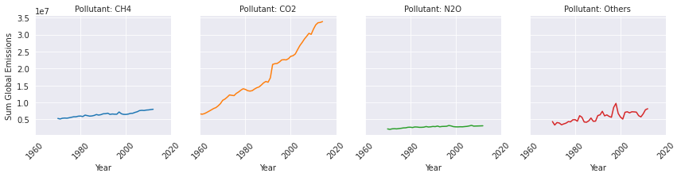

```python
sns.set_style("darkgrid")

g = sns.FacetGrid( Emissions_C_df_Resume,
                  col='Series_Code_1', hue='Series_Code_1', sharey = True)

g.set( xlim=(1960, 2020) )
g.map(sns.lineplot, 'Year', 'Indicator Value')
g.set_axis_labels(x_var="Year", y_var='Sum Global Emissions')
g.set_titles(col_template="Pollutant: {col_name}")
g.set_xticklabels(rotation = 45)
```

The trend graph shows an increase in the pollution emission trend for the different indicators. The largest pollutant in the world is CO<sub>2</sub>, in this sample we have CH<sub>4</sub> as the second pollutant. In all four indicators an upward trend is observed, although N<sub>2</sub>O emissions have remained constant.

#### 7.2

What can you say about the *distribution* of emissions around the globe over the years? What information can you extract from the *tails* of these distributions over the years?

**Answer.**

```python
Emissions_C_df_Resume_1 = Emissions_C_df\
.dropna(subset=['Indicator Value'])\
.query('Series_Code_1 in ["CO2", "CH4", "N2O", "PM2_5","Others"]')\
.groupby(['Series_Code_1', 'Country Name', 'Year'])\
.agg({'Indicator Value': 'sum'})\
.reset_index()

Emissions_C_df_Resume_1['Year'] = Emissions_C_df_Resume_1['Year'].astype('int')
Emissions_C_df_Resume_1['Decade'] = Emissions_C_df_Resume_1['Year'].map(lambda x:round(x / 10)*10)
```

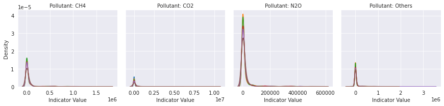

```python
g = sns.FacetGrid( Emissions_C_df_Resume_1,
                  col='Series_Code_1', hue='Decade',
                  sharex = False)
#
g.map(sns.kdeplot, 'Indicator Value')
g.set_axis_labels(x_var="Indicator Value", y_var='Density')
g.set_titles(col_template="Pollutant: {col_name}")
#
```

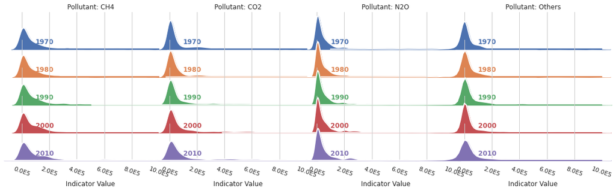

```python
sns.set_theme(style="whitegrid", rc={"axes.facecolor": (0, 0, 0, 0)})

dummy = Emissions_C_df_Resume_1\
[Emissions_C_df_Resume_1['Series_Code_1'].isin(["CO2", "CH4", "N2O", "Others"])]\
.query('Decade >= 1970 & Decade <= 2010')
#
dummy = dummy[dummy['Indicator Value'] <= 100000]
#
def label(x, color, label):
    ax = plt.gca()
    ax.text(0.1, .2, label, fontweight="bold", color=color,
            ha="left", va="center", transform=ax.transAxes)

g = sns.FacetGrid(dummy, row="Decade", hue="Decade", col= "Series_Code_1", aspect=4, height=1, margin_titles=True)
g.map(sns.kdeplot, "Indicator Value", fill=True, alpha=1, linewidth=1.5, bw_adjust=0.5, clip_on=False)
g.map(sns.kdeplot, "Indicator Value", clip_on=False, color="w", lw=2, bw_adjust=.5)
g.map(plt.axhline, y=0, lw=2, clip_on=False)
g.map(label, "Indicator Value")
g.fig.subplots_adjust(hspace=-.25)
g.set_titles("")
g.set(yticks=[], xlim=(0, 100000))
g.despine(bottom=True, left=True)
g.set_titles(col_template="Pollutant: {col_name}",row_template="")
#
xlabels = ['{:,.1f}'.format(float(x)/100000) + 'E5' for x in range(0, 1200000, 200000)]
g.set_xticklabels(xlabels, rotation=-20)
#
```

The distribution plot shows that some countries has exceptional large values of emissions, and distributions show a right skewness. These distributions show that most countries show no major changes over the decades. Emissions should be normalized by the population size of each country to have a better perspective of the emission *per capita* values.

#### 7.3

Compute a plot showing the behavior of each of the four main air pollutants for each of the main global regions in the `Emissions_R_df` data frame. The main regions are `'Latin America & Caribbean', 'South Asia', 'Sub-Saharan Africa', 'Europe & Central Asia', 'Middle East & North Africa', 'East Asia & Pacific'` and `'North America'`. What conclusions can you make?

**Answer.**

```python
regionsNames = ['Latin America & Caribbean', 'South Asia', 'Sub-Saharan Africa', 'Europe & Central Asia',
               'Middle East & North Africa','East Asia & Pacific','North America']

Emissions_R_df_1 = Emissions_R_df[ [i in regionsNames for i in Emissions_R_df['Country Name']] ]

Emissions_R_df_2 = Emissions_R_df_1\
.dropna(subset=['Indicator Value'])\
.query('Series_Code_1 in ["CO2", "CH4", "N2O", "Others"]')\
.groupby(['Country Name', 'Series_Code_1', 'Year'])\
.agg({'Indicator Value': 'sum'})\
.reset_index()
Emissions_R_df_2['Year'] = Emissions_R_df_2['Year'].astype(int)
```

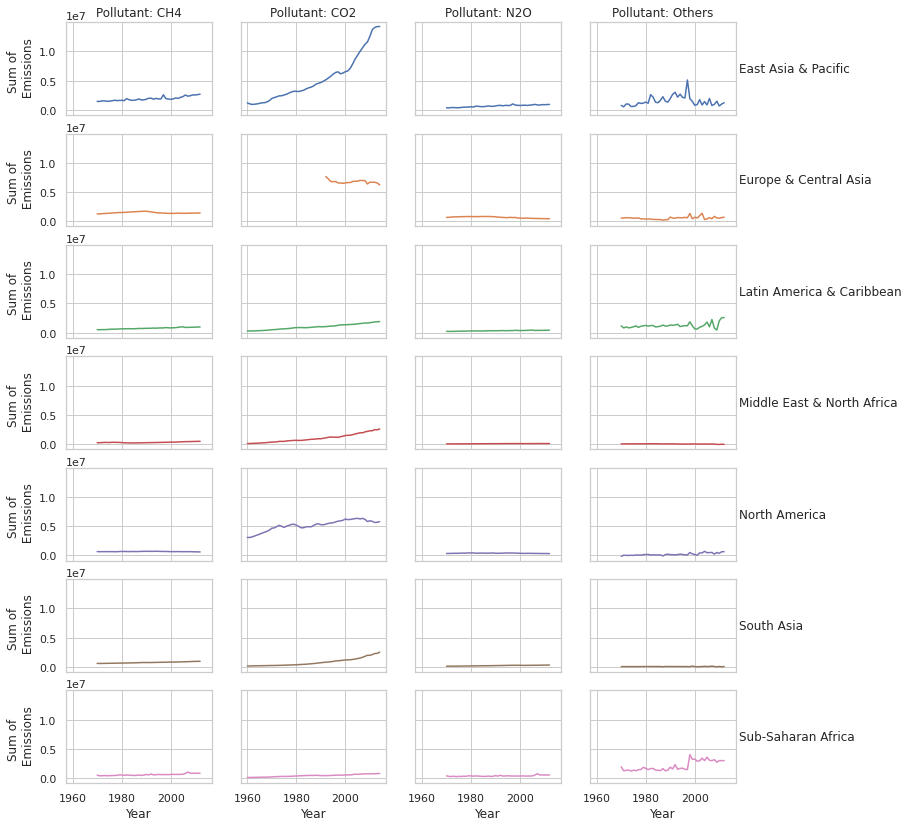

```python
sns.set_style('whitegrid', rc={"axes.facecolor": (1, 1, 1, 1)})

g = sns.FacetGrid( Emissions_R_df_2,
                  col='Series_Code_1', row='Country Name', hue='Country Name', height=2, aspect = 1.5,
                  sharey = True, margin_titles=True, despine=False, gridspec_kws={"hspace":0.2})
#
g.map(sns.lineplot, 'Year', 'Indicator Value')
g.set_axis_labels(x_var="Year", y_var='Sum of \n Emissions')
g.set_titles(col_template="Pollutant: {col_name}", row_template='{row_name}')

for ax in g.axes.flat:
    if ax.texts:
        txt = ax.texts[0]
        txt = ax.text(txt.get_unitless_position()[0], txt.get_unitless_position()[1],
                txt.get_text(),
                transform=ax.transAxes,
                va='center',
                rotation=0)
        ax.texts[0].remove()
```

### Exercise 8:

In Exercise 7 we discovered some interesting features of the distribution of the emissions over the years. Let us explore these features in more detail.

#### 8.1

Which are the top five countries that have been in the top 10 of `CO2` emitters over the years? Have any of these countries made efforts to reduce the amount of CO2 emissions over the last 10 years?

**Answer.**

```python
topCountries = Emissions_C_df.groupby('Country Name').sum().nlargest(10, 'Indicator Value').index
#
Emissions_topCountries = Emissions_C_df[
    (Emissions_C_df['Country Name'].isin(topCountries)) &
    (Emissions_C_df['Series_Code_1'].isin(["CO2", "CH4", "N2O", "PM2.5","Others"]))
]

Emissions_topCountries['Year'] = Emissions_topCountries['Year'].astype(int)
# Emissions_topCountries
```

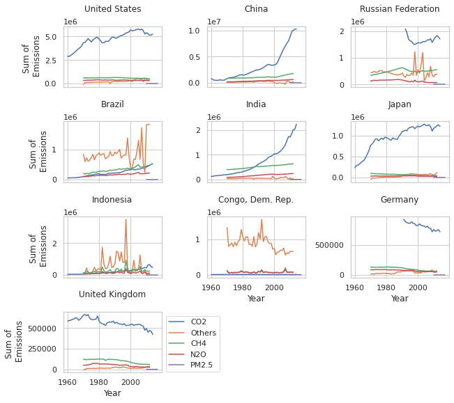

```python
g = sns.FacetGrid( Emissions_topCountries,
                  col='Country Name', hue='Series_Code_1',
                  height=2, aspect = 1.5, col_wrap = 3, col_order=topCountries,
                  sharey = False, margin_titles=True, despine=False, gridspec_kws={"hspace":0.2})
#
g.map(sns.lineplot, 'Year', 'Indicator Value')
g.set_axis_labels(x_var="Year", y_var='Sum of \n Emissions')
g.set_titles(col_template="{col_name}\n")
plt.legend(loc='upper left', bbox_to_anchor=(1,1))
```

Other countries such as Germany, the United Kingdom and Russia have shown a decrease in emissions. The rest of the countries (Brazil, Indonesia and the Congo) have shown a different emission profile than other concomitant HFCs, PFCs and SF6.

#### 8.2

Are these five countries carrying out the burden of most of the emissions emitted over the years globally? Can we say that the rest of the world is making some effort to control their polluted gasses emissions over the years?

**Answer.**

```python
# Lump other countries (not present in top 5) in a unique category
Emissions_C_df_Resume_1['Lump_Countries'] = [i if i in topCountries[0:5] else 'Others'
                                             for i in Emissions_C_df_Resume_1['Country Name'] ]
#
Emissions_C_df_Resume_2 = Emissions_C_df_Resume_1\
.groupby(['Series_Code_1', 'Lump_Countries', 'Decade'])\
['Indicator Value']\
.sum()\
.reset_index()
```

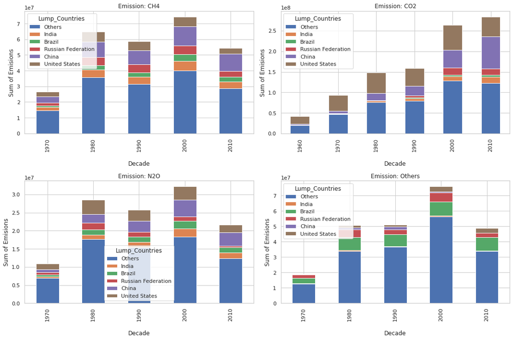

```python
CountriesOrder = list(topCountries[0:5])
CountriesOrder.append('Others')
CountriesOrder.reverse()
#
def stackedBarPlot(data, ind, ax):
    df = data[data['Series_Code_1'] == ind]\
    .pivot(index=['Decade'], columns='Lump_Countries', values='Indicator Value')\
    .loc[:, CountriesOrder]
    plot = df.plot.bar(ax=ax, stacked=True)
    plot.set(xlabel = '\nDecade', ylabel='Sum of Emisions')
    plot.set_title(f'Emission: {ind}')
    return(plot)

# Main indicators of emissions
indicators = Emissions_C_df_Resume_2['Series_Code_1'].unique()

fig, axes = plt.subplots(2,2,figsize=(15,10))
axes = axes.flatten()

for indic, ax in zip(indicators, axes):
    stackedBarPlot(Emissions_C_df_Resume_2, indic, ax)
fig.set_tight_layout(True)
#
```

As can be seen in the graphs, these top 5 countries with high emissions generate 50% of the global gas emission load. In most indicator gases with the exception of those contained in the "others" category.

We cannot affirm that the rest of the world is making improvements in reducing gas emissions. In the four indicators, an increase is observed between the decades of the 70s and 2000s, a decrease is observed in the decade of 2010s but this is due to the fact that data is not complete for the last years.

## The health impacts of air pollution

### Exercise 9:

One of the main contributions of poor health from air pollution is particulate matter. In particular, very small particles (those with a size less than 2.5 micrometres ($\mu$m)) can enter and affect the respiratory system. The `PM2.5` indicator measures the average level of exposure of a nation's population to concentrations of these small particles. The `PM2.5_WHO` measures the percentage of the population who are exposed to ambient concentrations of these particles that exceed some thresholds set by the World Health Organization (WHO). In particular, countries with a higher `PM2.5_WHO` indicator are more likely to suffer from bad health conditions.

#### 9.1

The client would like to know if there is any relationship between the `PM2.5_WHO` indicator and the level of income of the general population, as well as how this changes over time. What plot(s) might be helpful to solve the client's question? What conclusion can you draw from your plot(s) to answer their question?

**Hint:** The DataFrame `WDI_countries` contains a column named `Income Group`.

**Answer**

```python
Emissions_C_df['Year'] = Emissions_C_df['Year'].astype(int)

Emissions_C_df = Emissions_C_df\
.merge(WDI_Country.loc[:, ['Income Group', 'Country Code']], how='left', on='Country Code')
```

```python
# We could create an indicator consistent in a quantile vector for emissions by Income Group
Emissions_C_df_Resume_3 = Emissions_C_df\
.dropna(subset=['Indicator Value'])\
.query("Series_Code_1=='PM2.5_WHO'")\
.groupby(['Income Group', 'Year'])\
['Indicator Value']\
.quantile([.1, .5, .9])\
.reset_index()\
.rename(columns={'level_2':'quantile'})
#
Emissions_C_df_Resume_3['Year'] = Emissions_C_df_Resume_3['Year'].astype(int)
```

```python
Emissions_C_df_Resume_3\
.pivot(index=['Income Group', 'Year'], columns=['quantile'], values='Indicator Value').reset_index().head()
# .pivot(index=['Year'], columns=['Income Group', 'quantile'], values='Indicator Value').sort_index()
```

| quantile | Income Group | Year | 0.1 | 0.5 | 0.9 |
| --- | --- | --- | --- | --- | --- |
| 0 | High income | 1990 | 21.500707 | 99.981685 | 100.0 |
| 1 | High income | 1995 | 12.071917 | 99.981572 | 100.0 |
| 2 | High income | 2000 | 16.732073 | 99.957432 | 100.0 |
| 3 | High income | 2005 | 13.829863 | 99.967757 | 100.0 |
| 4 | High income | 2010 | 13.311523 | 99.956636 | 100.0 |

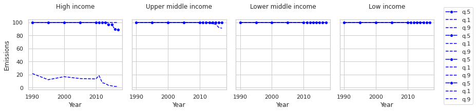

```python
income_order = ['High income', 'Upper middle income', 'Lower middle income', 'Low income']
#
g = sns.FacetGrid(
    (Emissions_C_df_Resume_3
     .pivot(index=['Income Group', 'Year'], columns=['quantile'], values='Indicator Value')
     .reset_index() ), col='Income Group', margin_titles=True,
                 col_order=income_order, despine=False,)
#
g.map(sns.lineplot, 'Year', 0.5, label='q.5', color='blue', linestyle='-', marker='o')
g.map(sns.lineplot, 'Year', 0.1, label='q.1', color='blue', linestyle='--')
g.map(sns.lineplot, 'Year', 0.9, label='q.9', color='blue', linestyle='--')
g.set_axis_labels(x_var="Year", y_var='Emissions')
g.set_titles(col_template="{col_name}\n")
g.fig.legend(loc='upper left', bbox_to_anchor=(1,1))
#
```

In the graph we can see that there is a high proportion of countries with exposure to these particles in most of the country's inhabitants. It is observed that there is a significant proportion of countries with populations that have low exposure in the group of rich countries. It is observed that in the last decade there has been an effort on the part of the countries to reduce the exposure of their citizens, this in countries with high and medium-high income.

#### 9.2

What do you think are the causes behind the results in Exercise 9.1?

**Answer.**

The decrease in environmental pollution in high-income countries may be due to government measures in these countries to reduce pollution. It is known that one of the primary sources of PM<sub>2.5</sub> generation is the burning of fossil fuels that occurs in automobiles and industries. In some regions such as the E.U., the automotive industry has been regulated to improve the quality of fuels (e.g. biodiesels), as well as the change to cleaner technology in cars and trucks (e.g. introduction of high performant filter in exhausts). On the other hand, the manufacturing industry has been regulated with a reduction in particulate emissions.

In low- and lower-middle income countries, we don't observe a decrease in this indicator. Governments in these countries may not have tough regulations in order to not affect the industry.

### Exercise 10:

Finally, our client is interested in investigating the impacts and relationships between **high levels of exposure to particle matter** and **the health of the population**. Coming up with additional data for this task may be infeasible for the client, thus they have asked us to search for relevant health data in the `WDIdata.csv` file and work with that.

#### 10.1

Which indicators present in the file `WDISeries.csv` file might be useful to solve the client's question? Explain.

**Note:** Naming one or two indicators is more than enough for this question.

**Answer.**

In this table we can see some indicators that could be related to levels of exposure to particle matter:

Mortality rate attributed to household and ambient air pollution, age-standardized (per 100,000 population) `SH.STA.AIRP.P5`

Life expectancy at birth, female (years)`SP.DYN.LE00.FE.IN`

Life expectancy at birth, total (years) `SP.DYN.LE00.IN`

Life expectancy at birth, male (years) `SP.DYN.LE00.MA.IN`

Survival to age 65, female (% of cohort) `SP.DYN.TO65.FE.ZS`

Survival to age 65, male (% of cohort) `SP.DYN.TO65.MA.ZS`

#### 10.2

Use the indicators provided in Exercise 10.1 to give valuable information to the client.

**Answer.**

```python
healthIndicators = ['SH.STA.AIRP.P5', 'SP.DYN.LE00.FE.IN', 'SP.DYN.LE00.IN', 'SP.DYN.LE00.MA.IN', 'SP.DYN.TO65.FE.ZS', 'SP.DYN.TO65.MA.ZS']
healthDF = WDI_data[ WDI_data['Indicator Code'].isin(healthIndicators) ]\
.melt(id_vars=['Country Name', 'Country Code', 'Indicator Name','Indicator Code'],
      value_vars=select_vars, var_name='Year', value_name='Indicator Value')\
.query("Year  != 'Unnamed: 64'")

healthDF['Year'] = healthDF['Year'].astype(int)

healthDF = healthDF\
.dropna(subset=['Indicator Value'])\
.pivot(index=['Country Name', 'Country Code', 'Year'], columns=['Indicator Code'], values=['Indicator Value'])\
.reset_index()
healthDF.head()
```

| Indicator Code | Country Name | Country Code | Year | Indicator Value SH.STA.AIRP.P5 | Indicator Value SP.DYN.LE00.FE.IN | Indicator Value SP.DYN.LE00.IN | Indicator Value SP.DYN.LE00.MA.IN | Indicator Value SP.DYN.TO65.FE.ZS | Indicator Value SP.DYN.TO65.MA.ZS |
| --- | --- | --- | --- | --- | --- | --- | --- | --- | --- |
| 0 | Afghanistan | AFG | 1960 | NaN | 33.314 | 32.446 | 31.718 | 21.478047 | 17.798288 |
| 1 | Afghanistan | AFG | 1961 | NaN | 33.840 | 32.962 | 32.224 | 22.105794 | 18.355259 |
| 2 | Afghanistan | AFG | 1962 | NaN | 34.359 | 33.471 | 32.724 | 22.733540 | 18.912230 |
| 3 | Afghanistan | AFG | 1963 | NaN | 34.866 | 33.971 | 33.216 | 23.331085 | 19.461949 |
| 4 | Afghanistan | AFG | 1964 | NaN | 35.364 | 34.463 | 33.700 | 23.928630 | 20.011668 |

```python
idxColumns = ['Country Name', 'Country Code', 'Income Group', 'Year']

health_Emissions_df = Emissions_C_df.pivot(idxColumns, ['Series_Code_1'], ['Indicator Value'])\
.reset_index()\
.merge(healthDF, how='left', on=['Country Name', 'Country Code', 'Year'])
#
health_Emissions_df.columns = health_Emissions_df.columns.map('|'.join).map(lambda x : x.replace(' ', '_'))
health_Emissions_df
```

|  | Country_Name\| | Country_Code\| | Income_Group\| | Year\| | Indicator_Value\|CH4 | Indicator_Value\|CO2 | Indicator_Value\|N2O | Indicator_Value\|Others | Indicator_Value\|PM2.5 | Indicator_Value\|PM2.5_WHO | Indicator_Value\|Total | Indicator_Value\|SH.STA.AIRP.P5 | Indicator_Value\|SP.DYN.LE00.FE.IN | Indicator_Value\|SP.DYN.LE00.IN | Indicator_Value\|SP.DYN.LE00.MA.IN | Indicator_Value\|SP.DYN.TO65.FE.ZS | Indicator_Value\|SP.DYN.TO65.MA.ZS |
| --- | --- | --- | --- | --- | --- | --- | --- | --- | --- | --- | --- | --- | --- | --- | --- | --- | --- |
| 0 | Afghanistan | AFG | Low income | 1960 | NaN | 414.371 | NaN | NaN | NaN | NaN | NaN | NaN | 33.314 | 32.446 | 31.718 | 21.478047 | 17.798288 |
| 1 | Afghanistan | AFG | Low income | 1961 | NaN | 491.378 | NaN | NaN | NaN | NaN | NaN | NaN | 33.840 | 32.962 | 32.224 | 22.105794 | 18.355259 |
| 2 | Afghanistan | AFG | Low income | 1962 | NaN | 689.396 | NaN | NaN | NaN | NaN | NaN | NaN | 34.359 | 33.471 | 32.724 | 22.733540 | 18.912230 |
| 3 | Afghanistan | AFG | Low income | 1963 | NaN | 707.731 | NaN | NaN | NaN | NaN | NaN | NaN | 34.866 | 33.971 | 33.216 | 23.331085 | 19.461949 |
| 4 | Afghanistan | AFG | Low income | 1964 | NaN | 839.743 | NaN | NaN | NaN | NaN | NaN | NaN | 35.364 | 34.463 | 33.700 | 23.928630 | 20.011668 |
| ... | ... | ... | ... | ... | ... | ... | ... | ... | ... | ... | ... | ... | ... | ... | ... | ... | ... |
| 13075 | Zimbabwe | ZWE | Lower middle income | 2015 | NaN | NaN | NaN | NaN | 21.733709 | 100.0 | NaN | NaN | 60.984 | 59.534 | 57.778 | 53.102397 | 46.031689 |
| 13076 | Zimbabwe | ZWE | Lower middle income | 2016 | NaN | NaN | NaN | NaN | 21.726947 | 100.0 | NaN | 133.0 | 61.719 | 60.294 | 58.565 | 54.448963 | 47.598672 |
| 13077 | Zimbabwe | ZWE | Lower middle income | 2017 | NaN | NaN | NaN | NaN | 22.251671 | 100.0 | NaN | NaN | 62.220 | 60.812 | 59.105 | 55.795529 | 49.165655 |
| 13078 | Zimbabwe | ZWE | Lower middle income | 2018 | NaN | NaN | NaN | NaN | NaN | NaN | NaN | NaN | NaN | NaN | NaN | NaN | NaN |
| 13079 | Zimbabwe | ZWE | Lower middle income | 2019 | NaN | NaN | NaN | NaN | NaN | NaN | NaN | NaN | NaN | NaN | NaN | NaN | NaN |

13080 rows × 17 columns

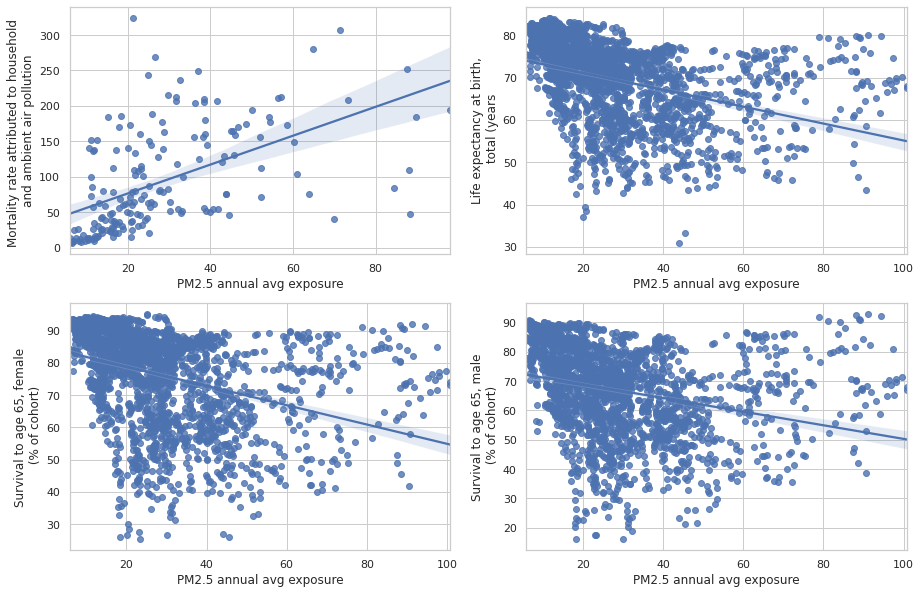

```python
fig, ax = plt.subplots(2, 2, figsize=(15,10))
#
sns.regplot(x= 'Indicator_Value|PM2.5', y='Indicator_Value|SH.STA.AIRP.P5', data=health_Emissions_df, ax=ax[0,0])
sns.regplot(x= 'Indicator_Value|PM2.5', y='Indicator_Value|SP.DYN.LE00.IN', data=health_Emissions_df, ax=ax[0,1])
sns.regplot(x= 'Indicator_Value|PM2.5', y='Indicator_Value|SP.DYN.TO65.FE.ZS', data=health_Emissions_df, ax=ax[1,0])
sns.regplot(x= 'Indicator_Value|PM2.5', y='Indicator_Value|SP.DYN.TO65.MA.ZS', data=health_Emissions_df, ax=ax[1,1])
#
ax[0,0].set(xlabel='PM2.5 annual avg exposure', ylabel='Mortality rate attributed to household \nand ambient air pollution')
ax[0,1].set(xlabel='PM2.5 annual avg exposure', ylabel='Life expectancy at birth,\n total (years')
ax[1,0].set(xlabel='PM2.5 annual avg exposure', ylabel='Survival to age 65, female\n (% of cohort)')
ax[1,1].set(xlabel='PM2.5 annual avg exposure', ylabel='Survival to age 65, male\n (% of cohort)')
#
print()
```

In the graph above it can be seen that there is a correlation of various mortality indicators with exposure to small particles. It is notable that the mortality indicator attributed to environmental pollution is correlated with the exposure to PM<sub>2.5</sub> particles, for different times and countries. On the other hand, there is an inversely proportional correlation between exposure to these particles and survival.

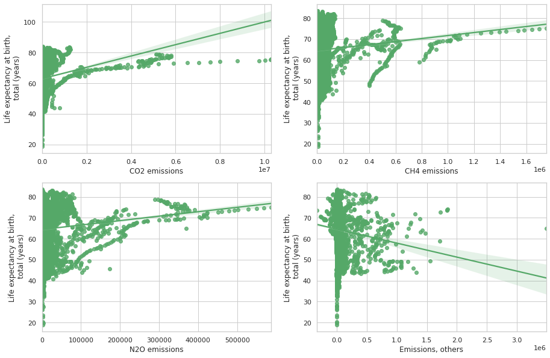

```python
fig, ax = plt.subplots(2, 2, figsize=(15,10))
#
sns.regplot(x= 'Indicator_Value|CO2', y='Indicator_Value|SP.DYN.LE00.IN', data=health_Emissions_df, ax=ax[0,0],color='g')
sns.regplot(x= 'Indicator_Value|CH4', y='Indicator_Value|SP.DYN.LE00.IN', data=health_Emissions_df, ax=ax[0,1],color='g')
sns.regplot(x= 'Indicator_Value|N2O', y='Indicator_Value|SP.DYN.LE00.IN', data=health_Emissions_df, ax=ax[1,0],color='g')
sns.regplot(x= 'Indicator_Value|Others', y='Indicator_Value|SP.DYN.LE00.IN', data=health_Emissions_df, ax=ax[1,1],color='g')
#
ax[0,0].set(xlabel='CO2 emissions', ylabel='Life expectancy at birth,\n total (years)')
ax[0,1].set(xlabel='CH4 emissions', ylabel='Life expectancy at birth,\n total (years)')
ax[1,0].set(xlabel='N2O emissions', ylabel='Life expectancy at birth,\n total (years)')
ax[1,1].set(xlabel='Emissions, others', ylabel='Life expectancy at birth,\n total (years)')
#
print()
```

The relationship between pollutant gas emissions and survival is not clear, since most countries have low levels of emissions and only a few have high levels of emissions. It seems that life expectancy is more related to quality of life in countries with high per capita income.

#### 10.3

Extend the analysis above to find some countries of interest. These are defined as

- The countries that have a high mortality rate due to household and ambient air pollution, but with low PM2.5 exposure
- The countries that have a low mortality rate due to household and ambient air pollution, but with high PM2.5 exposure

**Answer.**

```python
def getQuantile(array):
    quant = np.quantile(array, [0.25, 0.50, 0.75])
    mi = np.min(array)
    mx = np.max(array)
    n = len(array)

    let= np.empty(n, dtype=np.object)

    for i, vec in enumerate(array):
        try:
            if vec < quant[0] and vec>=mi:
                let[i] = 'Q1'
            elif vec <= quant[1]:
                let[i] = 'Q2'
            elif vec <= quant[2]:
                let[i] = 'Q3'
            else:
                let[i] = 'Q4'
        except:
            let[i] = 'NaN'

    return(let)

# vect_list = np.random.normal(0.0, 1, 100)
# print(getQuantile([1,2,1,4,5,1]))
```

```python
health_Emissions_df_1 = health_Emissions_df\
.groupby(['Country_Name|', 'Country_Code|', 'Income_Group|'])\
.mean().reset_index()
```

```python
health_Emissions_df_2 = health_Emissions_df_1\
.loc[:, ['Country_Name|', 'Income_Group|', 'Indicator_Value|PM2.5', 'Indicator_Value|SH.STA.AIRP.P5']]\
.dropna()
#
health_Emissions_df_2['PM2.5'] = getQuantile(health_Emissions_df_2['Indicator_Value|PM2.5'])
health_Emissions_df_2['SH.STA.AIRP.P5'] = getQuantile(health_Emissions_df_2['Indicator_Value|SH.STA.AIRP.P5'])
```

```python
# Cuntries that have a high mortality rate due to household and ambient air pollution, but with low PM2.5 exposure
health_Emissions_df_2[health_Emissions_df_2['PM2.5']=='Q1'][health_Emissions_df_2['SH.STA.AIRP.P5']=='Q4']
```

|  | Country_Name\| | Income_Group\| | Indicator_Value\|PM2.5 | Indicator_Value\|SH.STA.AIRP.P5 | PM2.5 | SH.STA.AIRP.P5 |
| --- | --- | --- | --- | --- | --- | --- |
| 112 | Liberia | Low income | 16.639204 | 170.2 | Q1 | Q4 |
| 128 | Micronesia, Fed. Sts. | Lower middle income | 12.951704 | 151.8 | Q1 | Q4 |
| 152 | Papua New Guinea | Lower middle income | 14.122967 | 152.0 | Q1 | Q4 |

```python
# Countries that have a low mortality rate due to household and ambient air pollution, but with high PM2.5 exposure
health_Emissions_df_2[health_Emissions_df_2['PM2.5']=='Q4'][health_Emissions_df_2['SH.STA.AIRP.P5'].isin(['Q1', 'Q2'])]
```

|  | Country_Name\| | Income_Group\| | Indicator_Value\|PM2.5 | Indicator_Value\|SH.STA.AIRP.P5 | PM2.5 | SH.STA.AIRP.P5 |
| --- | --- | --- | --- | --- | --- | --- |
| 2 | Algeria | Upper middle income | 36.021176 | 49.7 | Q4 | Q2 |
| 14 | Bahrain | High income | 67.693027 | 40.1 | Q4 | Q2 |
| 91 | Iran, Islamic Rep. | Upper middle income | 38.394122 | 50.9 | Q4 | Q2 |
| 148 | Oman | High income | 40.078498 | 53.9 | Q4 | Q2 |
| 159 | Qatar | High income | 87.222632 | 47.4 | Q4 | Q2 |
| 198 | Turkey | Upper middle income | 42.800573 | 46.6 | Q4 | Q2 |
| 204 | United Arab Emirates | High income | 39.758977 | 54.7 | Q4 | Q2 |

#### 10.4

Finally, we want to look at the mortality data by income. We expect higher income countries to have lower pollution-related mortality. Find out if this assumption holds. Calculate summary statistics and histograms for each income category and note any trends.

**Answer.**

```python
health_Emissions_df_2.groupby('Income_Group|')['Indicator_Value|PM2.5'].describe()
```

| Income_Group\| | count | mean | std | min | 25% | 50% | 75% | max |
| --- | --- | --- | --- | --- | --- | --- | --- | --- |
| High income | 52.0 | 20.687320 | 17.593590 | 6.710277 | 10.908189 | 15.207587 | 21.121596 | 87.222632 |
| Low income | 31.0 | 40.295558 | 17.437719 | 16.639204 | 28.866994 | 37.595149 | 47.399119 | 95.536044 |
| Lower middle income | 46.0 | 33.786990 | 17.431677 | 12.412512 | 22.268913 | 29.483340 | 40.596381 | 89.279674 |
| Upper middle income | 54.0 | 26.180683 | 11.448889 | 10.446438 | 17.943887 | 24.658050 | 29.724441 | 63.869427 |

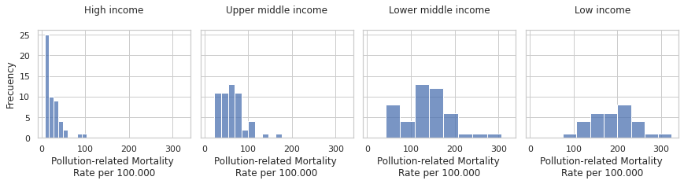

```python
g = sns.FacetGrid(health_Emissions_df_2, col='Income_Group|', margin_titles=True,
                 col_order=income_order, despine=False)
g.map(sns.histplot, 'Indicator_Value|SH.STA.AIRP.P5')
g.set_axis_labels(x_var="Pollution-related Mortality \nRate per 100.000", y_var='Frecuency')
g.set_titles(col_template="{col_name}\n")
```

As we can see in the graph, in countries with higher per capita income, lower mortality attributable to pollution is observed, compared to countries with lower per capita income.

#### 10.5

At the start, we asked some questions. Based on your analysis, provide a short answer to each of these:

1. Are we making any progress in reducing the amount of emitted pollutants across the globe?
2. Which are the critical regions where we should start environmental campaigns?
3. Are we making any progress in the prevention of deaths related to air pollution?
4. Which demographic characteristics seem to correlate with the number of health-related issues derived from air pollution?

**Answer.**

1. No, there are decreases in emissions in some countries, especially those with high per capita income. However, in developing economies such as China and India, there is an astronomical increase in emissions figures that generate a positive balance worldwide.
2. Emergency interventions should be started in developing economies as they are the main producers, and we should try plans to reduce emissions in countries with low per capita income start.
3. Yes, there are countries with successful experiences in reducing mortality from gas pollution. Policies should be implemented in developing countries to prevent mortality from these causes.
4. With the data available in this study, the relationship between life expectancy and mortality was only visible with exposure to air pollution. The study should be complemented with more health data to find out which are the diseases most linked to exposure to air pollution.